# PRS_Uncertainty

Author

Sarah Urbut

Published

March 7, 2024

## Correlation

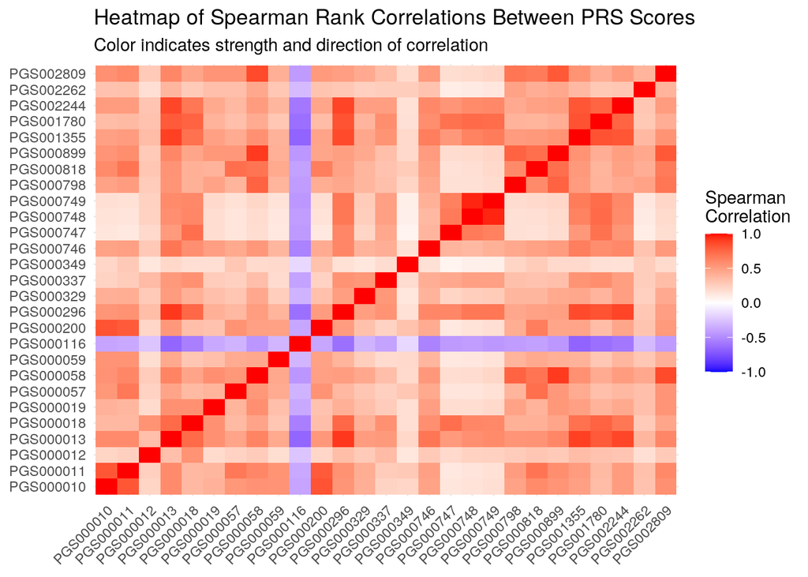

```r
library(data.table)
library(Hmisc)
library(irr)
library(ggplot2)

df=fread("codefrombuu/sarah/pheno_prs_cad.txt")
d=df[, .SD, .SDcols = patterns("PGS")]
d=data.frame(apply(d,2,scale))
d$id=df$IID
dt=df=data.table(d)
# Calculate the Spearman rank correlations between each pair of PRS scores

prs_columns <- grep("PGS", names(dt), value = TRUE)

# Calculate the Spearman rank correlations between each pair of PRS scores
cor_matrix <- rcorr(as.matrix(df[, ..prs_columns]), type = "spearman")

# Convert the correlation matrix to a format suitable for ggplot
cor_data <- melt(cor_matrix$r)
names(cor_data) <- c("Variable1", "Variable2", "Correlation")

# Create the heatmap
ggplot(cor_data, aes(x = Variable1, y = Variable2, fill = Correlation)) +
  geom_tile() +  # Use geom_tile() to create the heatmap tiles
  scale_fill_gradient2(low = "blue", high = "red", mid = "white",
                       midpoint = 0, limit = c(-1, 1), space = "Lab",
                       name="Spearman\nCorrelation") +
  theme_minimal() +  # Minimal theme to keep focus on the data
  theme(axis.text.x = element_text(angle = 45, hjust = 1),  # Rotate x axis labels
        axis.title = element_blank()) +  # Remove axis titles
  labs(title = "Heatmap of Spearman Rank Correlations Between PRS Scores",
       subtitle = "Color indicates strength and direction of correlation")
```

To look at the distribtuion of correlation:

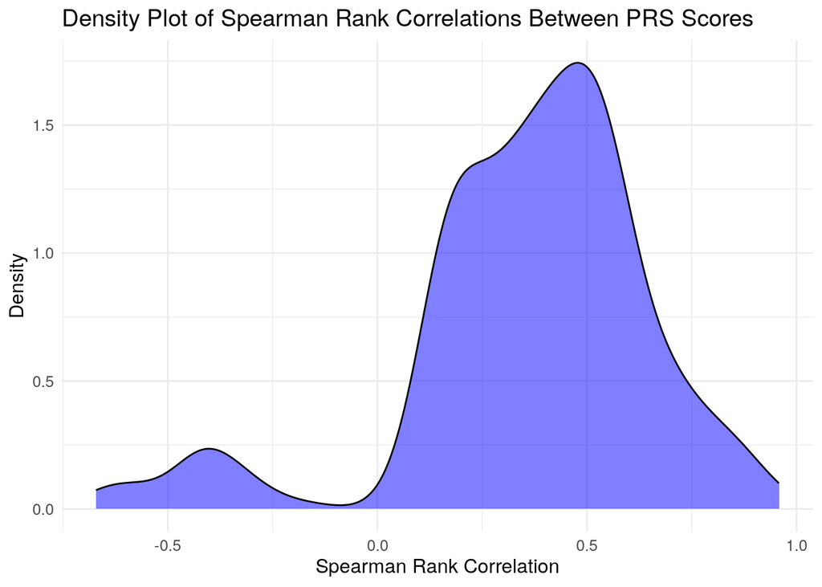

```r
# Extract the upper triangle of the correlation matrix, excluding the diagonal
cor_values <- cor_matrix$r[upper.tri(cor_matrix$r)]

# Convert to data frame for ggplot
cor_data <- data.frame(Correlation = cor_values)

# Create the density plot
ggplot(cor_data, aes(x = Correlation)) +
  geom_density(fill="blue", alpha=0.5) +
  ggtitle("Density Plot of Spearman Rank Correlations Between PRS Scores") +
  xlab("Spearman Rank Correlation") +
  ylab("Density") +
  theme_minimal() +
  theme(text = element_text(size=12))
```

We might wish to understand the reliability of this performance, and so we can bootstrap the samples to see how often the spearman rank correatlion is consistent with this number. For example, we bootstrap the spearman rank correlation for scores 1 and 2:

```r
library(boot)

spearman_bootstrap <- function(data, indices, col1, col2) {
  # Subset data based on bootstrap sample indices and select only the specified columns
  sampled_data <- data[indices, .(score1 = get(col1), score2 = get(col2))]
  # Calculate the Spearman correlation between the two specified scores
  cor(sampled_data$score1, sampled_data$score2, method = "spearman")
}

# Example of bootstrapping the correlation between the first two PRS scores
prs_columns <- grep("PGS", names(dt), value = TRUE)  # Assuming all PRS scores start with 'PGS'
boot_obj <- boot(data = dt, statistic = spearman_bootstrap, R = 1000, col1 = prs_columns[1], col2=prs_columns[2])
print(boot_obj)
```

```
ORDINARY NONPARAMETRIC BOOTSTRAP


Call:
boot(data = dt, statistic = spearman_bootstrap, R = 1000, col1 = prs_columns[1],
    col2 = prs_columns[2])


Bootstrap Statistics :
     original        bias    std. error
t1* 0.8176138 -0.0002273965 0.004304238
```

## Intra class correlation

```r
library(irr)
# Assuming each row is an individual and each column is a different PRS measurement
icc_results <- icc(as.matrix(dt[, ..prs_columns]), model = "twoway", type = "consistency")
print(icc_results)
```

```
 Single Score Intraclass Correlation

   Model: twoway
   Type : consistency

   Subjects = 7393
     Raters = 27
   ICC(C,1) = 0.373

 F-Test, H0: r0 = 0 ; H1: r0 > 0
F(7392,192192) = 17.1 , p = 0

 95%-Confidence Interval for ICC Population Values:
  0.365 < ICC < 0.381
```

### Understanding the ICC Output

**ICC(C,1) = 0.373** - This is the value of the ICC under the model and type specified. An ICC of 0.373 suggests moderate consistency. It means that approximately 37.3% of the total variance in the PRS scores can be attributed to differences between individuals. This level of ICC indicates that while there is some consistency in how individuals are ranked across different PRS scores, there is also a significant amount of variability that is not attributable to differences between individuals.

- **F(7392,192192) = 17.1, p = 0**
- The F statistic is 17.1, and the p-value is extremely small (essentially zero), indicating that the ICC is significantly different from zero. This confirms that the PRS scores are not randomly assigned and that they provide some meaningful differentiation between individuals.
7. **95%-Confidence Interval for ICC Population Values: 0.365 < ICC < 0.38**
   - This confidence interval provides a range of values within which the true ICC is expected to lie with 95% confidence. The narrow range around the ICC estimate further supports its stability and reliability.

### Practical Implications

The ICC value of 0.373, while indicating some consistency, is not particularly high, which could imply several things: - There might be a need to investigate whether some PRS scores are not performing as well as others. - The moderate ICC suggests that while the PRS scores can distinguish individuals to some extent, their use might be limited in contexts requiring high reliability (e.g., clinical settings). - Efforts to improve the consistency of these scores might include refining the algorithms or models used to calculate them, or possibly selecting or weighting some scores more than others based on their performance.

In summary, this ICC analysis gives you a quantitative measure of how reliably different PRS scores rank the same individuals. While showing some ability to differentiate between individuals, the consistency is not very strong, indicating room for improvement in PRS methodology or selection.

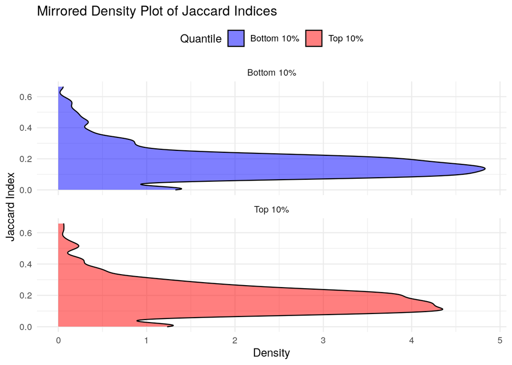

```r
prs_columns <- grep("PGS", names(dt), value = TRUE)
dt=data.table(d)
library(data.table)
df=dt
prs_columns <- grep("PGS", names(df), value = TRUE)

# Calculate ranks and determine top/bottom 10%
df[, (prs_columns) := lapply(.SD, rank, ties.method = "average"), .SDcols = prs_columns]
df[, paste0(prs_columns, "_top10") := lapply(.SD, function(x) x > quantile(x, 0.9, names = FALSE)), .SDcols = prs_columns]
df[, paste0(prs_columns, "_bottom10") := lapply(.SD, function(x) x < quantile(x, 0.1, names = FALSE)), .SDcols = prs_columns]

# Prepare to compare pairs
top_10_cols <- grep("_top10", names(df), value = TRUE)
bottom_10_cols <- grep("_bottom10", names(df), value = TRUE)
top_jaccard <- vector("list", length = length(prs_columns))
bottom_jaccard <- vector("list", length = length(prs_columns))

# Compare each pair of scores for top 10% and bottom 10%
for (i in seq_along(prs_columns)) {
  for (j in seq_along(prs_columns)) {
    if (i != j) {
      # Calculate Jaccard index for top 10%
      top_intersection <- sum(df[[top_10_cols[i]]] & df[[top_10_cols[j]]])
      top_union <- sum(df[[top_10_cols[i]]] | df[[top_10_cols[j]]])
      top_jaccard[[i]] <- c(top_jaccard[[i]], top_intersection / top_union)

      # Calculate Jaccard index for bottom 10%
      bottom_intersection <- sum(df[[bottom_10_cols[i]]] & df[[bottom_10_cols[j]]])
      bottom_union <- sum(df[[bottom_10_cols[i]]] | df[[bottom_10_cols[j]]])
      bottom_jaccard[[i]] <- c(bottom_jaccard[[i]], bottom_intersection / bottom_union)
    }
  }
}

# Convert lists to vectors
top_jaccard <- unlist(top_jaccard)
bottom_jaccard <- unlist(bottom_jaccard)

# Prepare data for ggplot
jaccard_data <- data.frame(
  Jaccard = c(top_jaccard, bottom_jaccard),
  Quantile = c(rep("Top 10%", length(top_jaccard)), rep("Bottom 10%", length(bottom_jaccard)))
)

# Create the mirrored density plot
ggplot(jaccard_data, aes(x = Jaccard, fill = Quantile)) +
  geom_density(alpha = 0.5) +
  facet_wrap(~Quantile, scales = "free_y", ncol = 1) +
  scale_fill_manual(values = c("blue", "red")) +
  coord_flip() +
  theme_minimal() +
  labs(title = "Mirrored Density Plot of Jaccard Indices",
       x = "Jaccard Index",
       y = "Density") +
  theme(legend.position = "top")
```

Or

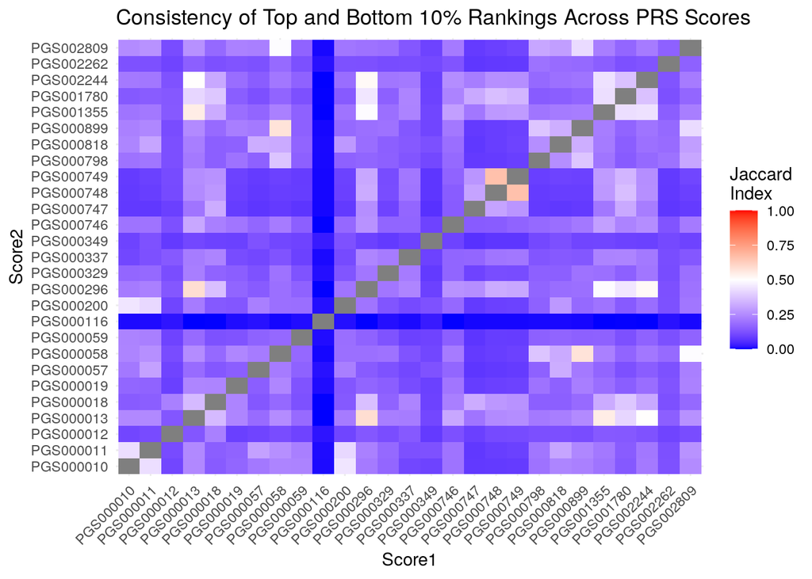

```r
prs_columns <- grep("PGS", names(dt), value = TRUE)
dt=data.table(d)
library(data.table)
df=dt
prs_columns <- grep("PGS", names(df), value = TRUE)


# Calculate ranks and determine top/bottom 10%
df[, (prs_columns) := lapply(.SD, rank, ties.method = "average"), .SDcols = prs_columns]
df[, paste0(prs_columns, "_top10") := lapply(.SD, function(x) x > quantile(x, 0.9, names = FALSE)), .SDcols = prs_columns]
df[, paste0(prs_columns, "_bottom10") := lapply(.SD, function(x) x < quantile(x, 0.1, names = FALSE)), .SDcols = prs_columns]

# Prepare to compare pairs
top_10_cols <- grep("_top10", names(df), value = TRUE)
bottom_10_cols <- grep("_bottom10", names(df), value = TRUE)
consistency_matrix <- matrix(nrow = length(prs_columns), ncol = length(prs_columns), dimnames = list(prs_columns, prs_columns))

top_mat <- matrix(nrow = length(prs_columns), ncol = length(prs_columns), dimnames = list(prs_columns, prs_columns))

bot_mat <- matrix(nrow = length(prs_columns), ncol = length(prs_columns), dimnames = list(prs_columns, prs_columns))
# Compare each pair of scores for top 10% and bottom 10%
for (i in seq_along(prs_columns)) {
  for (j in seq_along(prs_columns)) {
    if (i != j) {
      # Calculate Jaccard index for top 10%
      top_intersection <- sum(df[[top_10_cols[i]]] & df[[top_10_cols[j]]])
      top_union <- sum(df[[top_10_cols[i]]] | df[[top_10_cols[j]]])
      jaccard_top <- top_intersection / top_union

      # Calculate Jaccard index for bottom 10%
      bottom_intersection <- sum(df[[bottom_10_cols[i]]] & df[[bottom_10_cols[j]]])
      bottom_union <- sum(df[[bottom_10_cols[i]]] | df[[bottom_10_cols[j]]])
      jaccard_bottom <- bottom_intersection / bottom_union

      # Store average of top and bottom Jaccard indices
      consistency_matrix[i, j] <- (jaccard_top + jaccard_bottom) / 2
      top_mat[i, j] <- (jaccard_top)
      bot_mat[i, j] <- (jaccard_bottom)
    }
  }
}

# Visualize the consistency matrix
library(ggplot2)
library(reshape2)
melted_consistency_matrix <- melt(consistency_matrix, varnames = c("Score1", "Score2"))
ggplot(melted_consistency_matrix, aes(x = Score1, y = Score2, fill = value)) +
  geom_tile() +
  scale_fill_gradient2(low = "blue", high = "red", midpoint = 0.5, mid = "white", limit = c(0, 1), name = "Jaccard\nIndex") +
  theme_minimal() +
  theme(axis.text.x = element_text(angle = 45, hjust = 1)) +
  labs(title = "Consistency of Top and Bottom 10% Rankings Across PRS Scores")
```

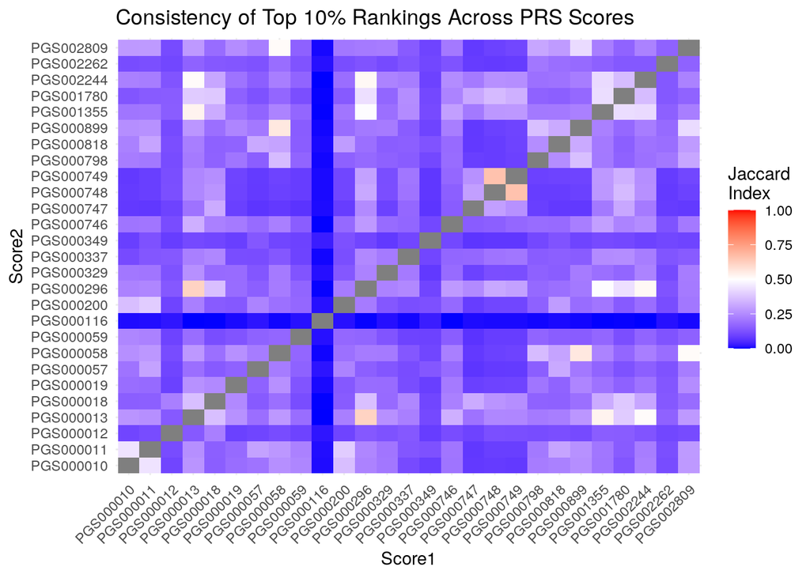

```r
melted_consistency_matrix <- melt(top_mat, varnames = c("Score1", "Score2"))
ggplot(melted_consistency_matrix, aes(x = Score1, y = Score2, fill = value)) +
  geom_tile() +
  scale_fill_gradient2(low = "blue", high = "red", midpoint = 0.5, mid = "white", limit = c(0, 1), name = "Jaccard\nIndex") +
  theme_minimal() +
  theme(axis.text.x = element_text(angle = 45, hjust = 1)) +
  labs(title = "Consistency of Top 10% Rankings Across PRS Scores")
```

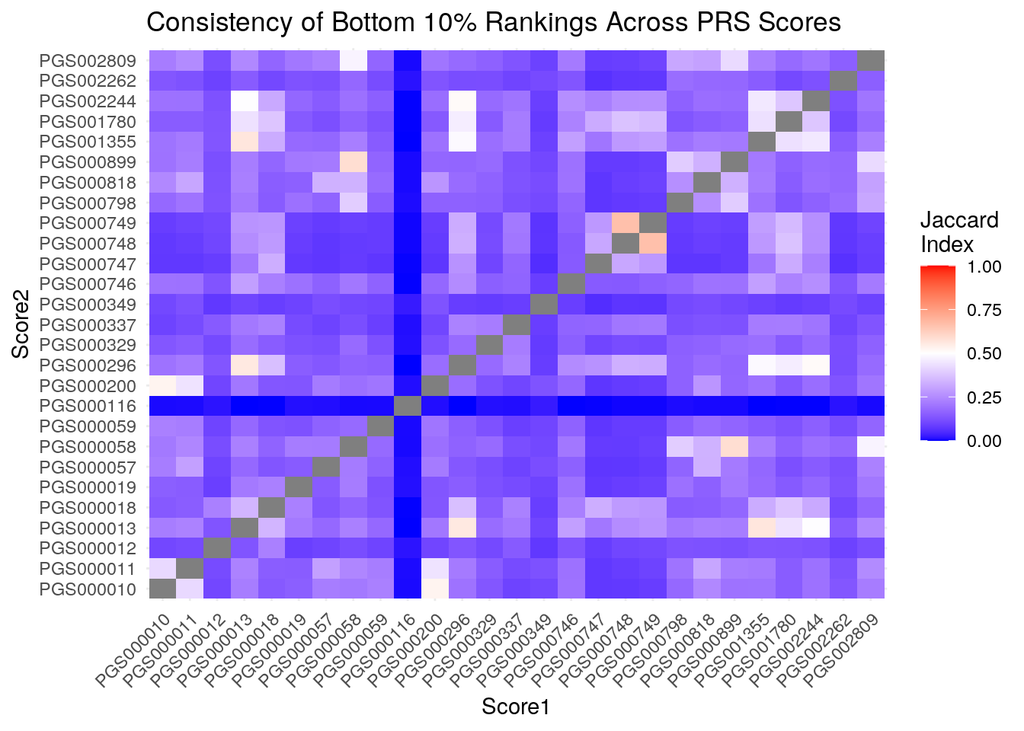

```r
melted_consistency_matrix <- melt(bot_mat, varnames = c("Score1", "Score2"))
ggplot(melted_consistency_matrix, aes(x = Score1, y = Score2, fill = value)) +
  geom_tile() +
  scale_fill_gradient2(low = "blue", high = "red", midpoint = 0.5, mid = "white", limit = c(0, 1), name = "Jaccard\nIndex") +
  theme_minimal() +
  theme(axis.text.x = element_text(angle = 45, hjust = 1)) +
  labs(title = "Consistency of Bottom 10% Rankings Across PRS Scores")
```

[output not shown]